# Interpolate: Repairing Gaps in Tracking Data

`interpolate()` repairs gaps in motion data by constructing a dense and evenly spaced time grid at the target frame rate. In other words, we use this step to fill missing positions.

## 1. Why we interpolate

When we are filtering or calculating derivatives like velocity, we assume our data is evenly spaced (ie., there is one row every 10th of a second for every coordinate). Unfortunately, devices drop out so this is not always true Interpolation allows us to make an educated guess on what the coordinate *should be* when drop outs occur. This is another thing that is usually done by providers, but is useful to check when publishing a paper.

## 2. Basic usage

Here, you just need to set the interpolation method (explained more depth below), the sample rate and the maximum gap in frames. We set a max gap in frames, because sometimes dropouts can be *so extreme* that our ability to make an educated guess becomes questionable. In the example below, we fill any drop outs less than 20 samples (2 seconds, because 10 Hz x 2 seconds = 20). But if there was a drop out of, for example, ten thousand seconds, then we truly have no idea where the player was in that time. All interpolation methods can only connect “when we saw the player last” to “when we see them again”.

```r
trace <- trace_pre |>
  interpolate(
    method         = "linear",
    hz             = 10,
    max_gap_frames = 20    # fill gaps up to 2 seconds; leave larger ones as NA
  )
```

## 3. Visualising the `is_interpolated` flag

Every filled row receives `is_interpolated = TRUE`. You can see exactly which positions are real and which are estimated. In our example, there is nothing to estimate, as it has been done by the provider.

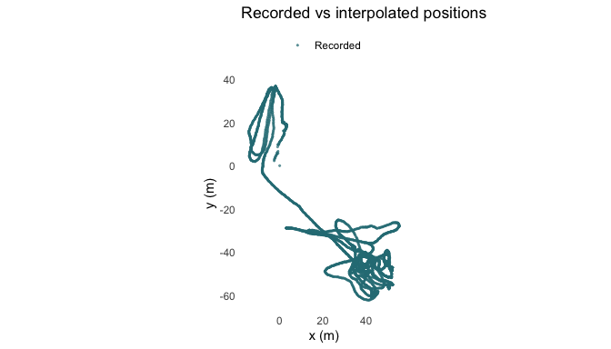

```r
trace |>
  filter(!is.na(x)) |>
  ggplot(aes(x = x, y = y, colour = is_interpolated)) +
  geom_point(size = 0.4, alpha = 0.6) +
  coord_fixed() +
  scale_colour_manual(
    values = c("FALSE" = "#2B7C85", "TRUE" = "#FF6F59"),
    labels = c("FALSE" = "Recorded", "TRUE" = "Interpolated")
  ) +
  labs(
    title  = "Recorded vs interpolated positions",
    x      = "x (m)", y = "y (m)", colour = NULL
  ) +
  theme_minimal() +
  theme(panel.grid = element_blank(), legend.position = "top")
```

In a well-functioning GPS session most points should be blue. Clusters of red indicate where the signal dropped and linear fill was used.

A spatial plot shows *where* gaps occurred. A time-series plot shows *when* they occurred and how the filled values connect to the surrounding real data:

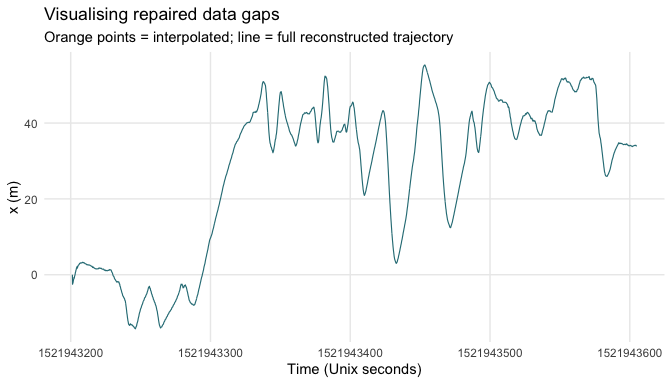

```r
trace |>
  filter(!is.na(x)) |>
  ggplot(aes(x = unix_time, y = x)) +
  geom_line(colour = "#2B7C85", linewidth = 0.4) +
  geom_point(
    data  = \(d) filter(d, is_interpolated),
    colour = "#FF6F59", size = 1.2
  ) +
  labs(
    title    = "Visualising repaired data gaps",
    subtitle = "Orange points = interpolated; line = full reconstructed trajectory",
    x = "Time (Unix seconds)", y = "x (m)"
  ) +
  theme_minimal() +
  theme(panel.grid.minor = element_blank())
```

Each orange point is a position the package estimated rather than recorded. A short isolated cluster means a brief signal hiccup — fine to keep. A long run of orange covering a sharp directional change is worth scrutinising before running kinematics.